# DATA605 - Week 5

Christian Thieme

9/24/2020

# **Probability Distributions**

### Choose independently two numbers B and C at random from the interval [0, 1] with uniform density. Prove that B and C are proper probability distributions. Note that the point (B,C) is then chosen at random in the unit square.

We will use the `runif` function in R to pick two numbers from the interval [0,1] with uniform density. In looking at B, we can see that this is a proper probability distribution as we pulled 100,000 different probabilities and 100% of them fall within the interval [0,1]. Additionally, we can see that this is a uniform distribution.

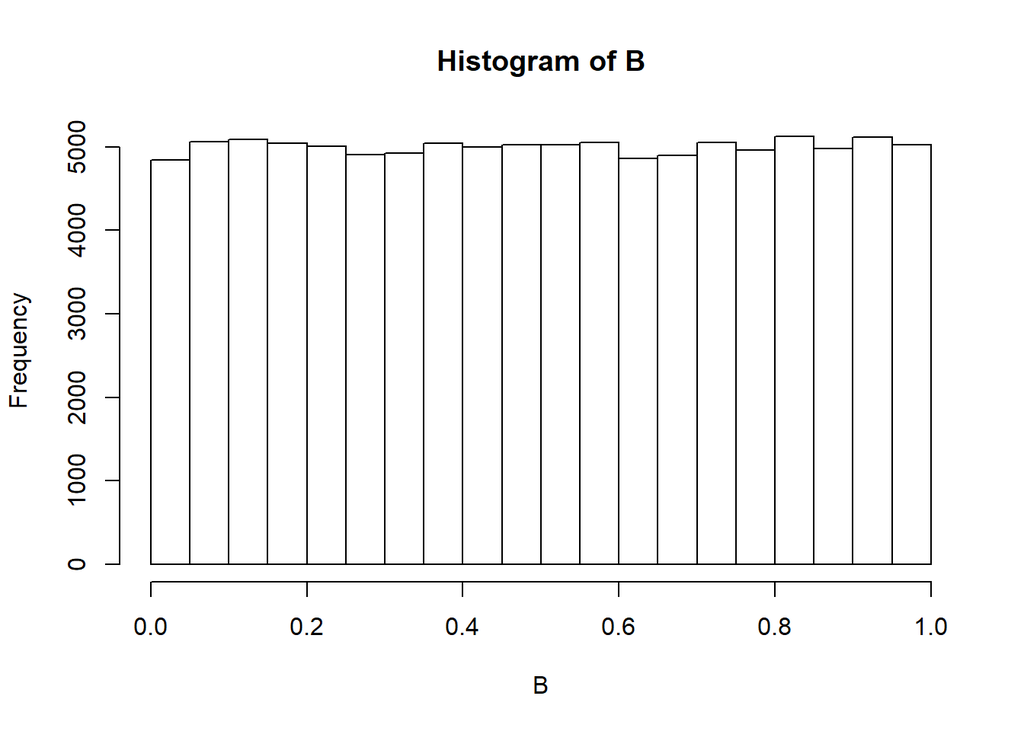

```r
B <- runif(100000)
hist(B)
```

The same is true of C:

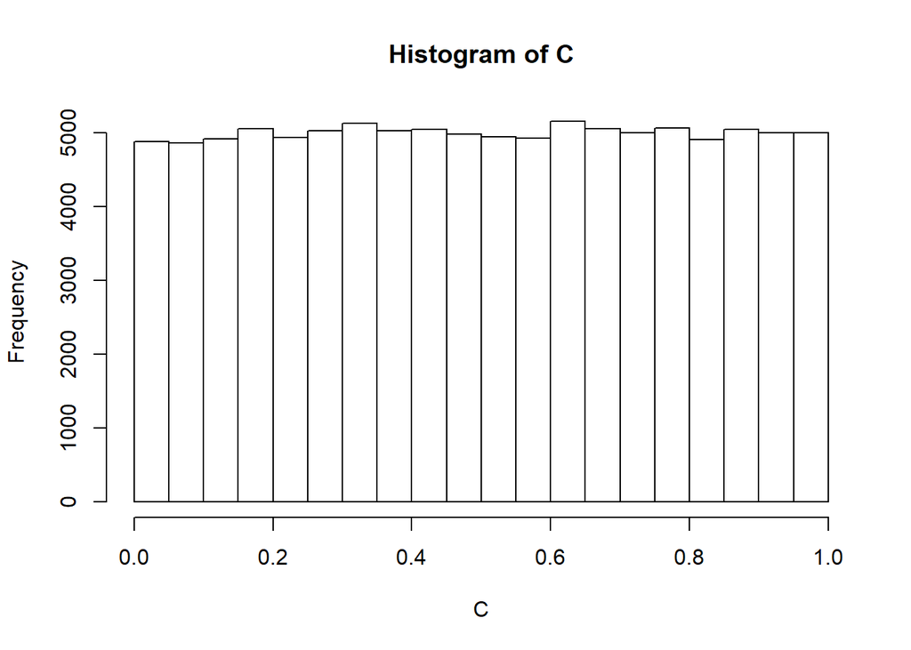

```r
C <- runif(100000)
hist(C)
```

As both values fall within the interval [0,1], the combined interval with fall between [0,2] 100% of the time.

We will use a simlulation to solve the questions below. Given that we have 100K probabilities for both B and C, the law of large numbers should help us get incredibly close to the probabliity we would have calculated manually.

```r
counter <- 0

for (i in seq(length(B))) {
  if (B[i] + C[i] < 0.5) {
    counter <- counter + 1
  } else {
    next()
  }
}

prob1 <- counter / length(B)
```

### (b) Find the probability that BC < 1/2

```r
counter <- 0

for (i in seq(length(B))) {
  if (B[i] * C[i] < 0.5) {
    counter <- counter + 1
  } else {
    next()
  }
}

prob2 <- counter / length(B)
```

#### The probability that BC < 1/2 is approximately: 0.84524.

### (c) Find the probability that |B - C| < 1/2

```r
counter <- 0

for (i in seq(length(B))) {
  if (abs(B[i] - C[i]) < 0.5) {
    counter <- counter + 1
  } else {
    next()
  }
}

prob3 <- counter / length(B)
```

#### The probability that |B - C| < 1/2 is approximately: 0.74953.

### (d) Find the probability that max{B,C} < 1/2

```r
counter <- 0

for (i in seq(length(B))) {
  if (max(B[i], C[i]) < 0.5) {
    counter <- counter + 1
  } else {
    next()
  }
}

prob4 <- counter / length(B)
```

#### The probability that max{B,C} < 1/2 is approximately: 0.24943.

### (e) Find the probability that min{B,C} < 1/2

```r
counter <- 0

for (i in seq(length(B))) {
  if (min(B[i], C[i]) < 0.5) {
    counter <- counter + 1
  } else {
    next()
  }
}

prob5 <- counter / length(B)
```

#### The probability that min{B,C} < 1/2 is approximately: 0.74853.